# How to Visualize Binary Outcomes in Research

TF

2018-06-16

In my research I frequently want visualize outcomes over groups. The nature of clinical reserach means that often times outcomes are binary and I want to find the proportion of binary outcomes over groups. This was not straight forward for me, so I decided to make a post about it.

###load libraries

```r
library(tidyverse)
library(ggpubr)
```

###create the variables

```r
set.seed(15762)
death<-rbinom(1000,1,0.03)
readmit <-rbinom(1000,1, 0.1)
id<-rbinom(1000,5,0.2)
```

###combine into dataframe

```r
x <- data.frame(death,readmit,id)
names(x) <- c("death", "readmit", "id")
```

###check the results

```r
head(x)
```

|  | death | readmit | id |
| --- | --- | --- | --- |
| 1 | 0 | 0 | 2 |
| 2 | 0 | 0 | 0 |
| 3 | 0 | 0 | 0 |
| 4 | 0 | 0 | 3 |
| 5 | 0 | 0 | 2 |
| 6 | 0 | 0 | 0 |

Now here is where it was tricky for me. If you, like I typically do, work with large data then you will need to extract the components you want. Typically for the specific outcome I am interested in, i’ll use `na.omit(df)` to restrict to only observations with all outcomes observed; excluding NAs

So once you do that you want to select out the binary outcome you are interested in, and I will be using death as the outcome to evaluate.

###pull out the observations I am interested in the proportion of death across different IDs

```r
death_x <-dplyr::select(x, death, id)
```

###create proportion table to get proportion of deaths across different IDs

```r
death_prop <- death_x %>% count(death, id) %>% mutate(prop=prop.table(n))
```

###now just look at the proportion of those that died; this next step basically makes sure we only visualize the proportion of death

```r
death_prop <- dplyr::filter(death_prop, death==1)
```

###then just graph it; ive chosen to use a lollipop plot, because I think that is the best

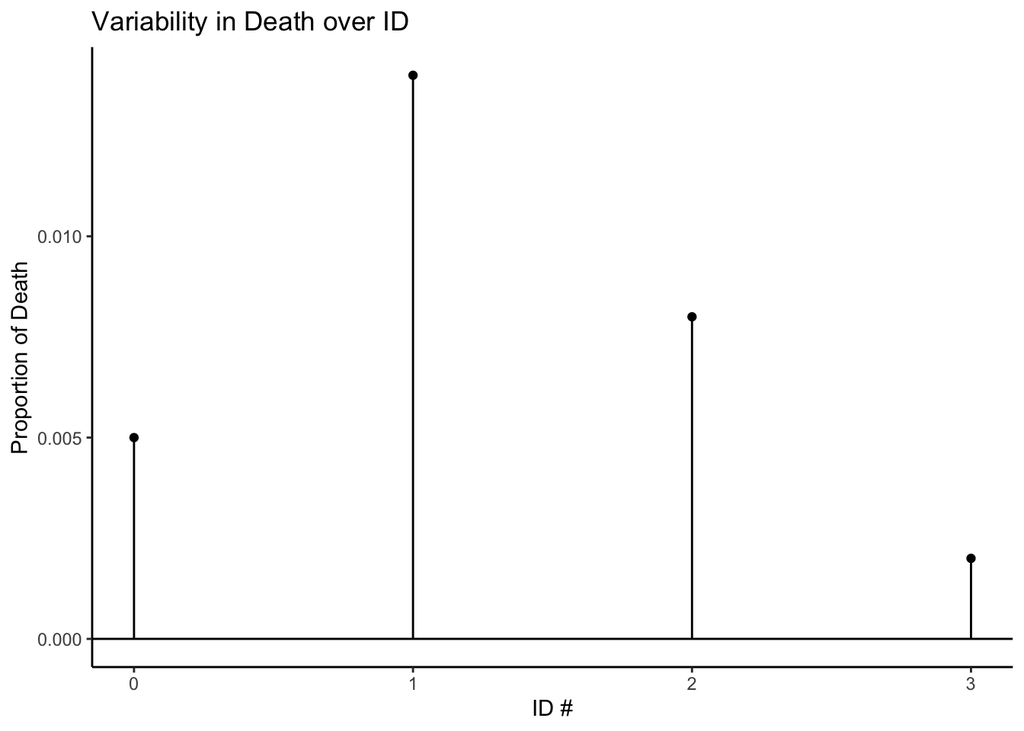

```r
ggplot(death_prop, aes(x=id, y=prop)) +
  geom_point() +
  geom_segment( aes(x=id, xend=id, y=0, yend=prop))+theme_classic()+geom_hline(aes(yintercept=0))+labs(x="ID #", y="Proportion of Death", title="Variability in Death over ID")
```